# > **Tip**: Welcome to the Investigate a Dataset project! You will find tips in quoted sections like this to help organize your approach to your investigation. Before submitting your project, it will b

## Data Wrangling

> **Tip**: In this section of the report, you will load in the data, check for cleanliness, and then trim and clean your dataset for analysis. Make sure that you document your steps carefully and justify your cleaning decisions.

### General Properties

```python
5.Top 5 directors who have been described based on revenue and budget?
```

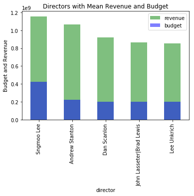

```python
# I am using the data to group directors based on budget and revenue.
# i am grouping the director and finding the mean for the revenue and budget column
counting=news.groupby('director').revenue.mean()
counting1=news.groupby('director').budget.mean()
# Using the bar chart to plot the graph for top 5 directors based on revenue and budget
counting.nlargest(5).plot(kind='bar',alpha=0.5,color='green',label='revenue')
counting1.nlargest(5).plot(kind='bar',alpha=0.5,color='blue',label='budget')
mp.title('Directors with Mean Revenue and Budget')
mp.ylabel('Budget and Revenue')
mp.legend();
```

```python
6.How does the popularity for movie increases based on last 15 years?
```

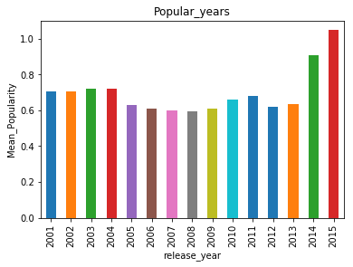

```python
# From this i have splitted the year of releasing after 2000 since there is too much data
# The data is then gouped by release year and mean of popularity using the bar chart.

latest=news.query('release_year>2000')
latestpop1=latest.groupby('release_year').popularity.mean().plot(kind='bar',title='Popular_years')
latestpop1.set(ylabel="Mean_Popularity");
```

```python
7.Top 5 directors based on popularity?
```

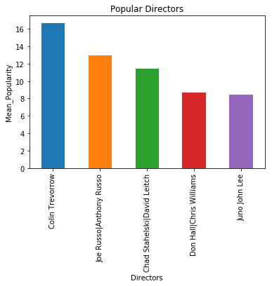

```python
#Since popularity is our dependent variable. These are our popular directors based on popularity
#we are grouping by directors and finding the mean of the values.
counting=news.groupby('director').popularity.mean()
#counting
plot1=counting.nlargest(5).plot(kind='bar',title='Popular Directors')
plot1.set(xlabel="Directors", ylabel="Mean_Popularity");
```

```python
8. How does the popularity differ based on Lead Actors?
```

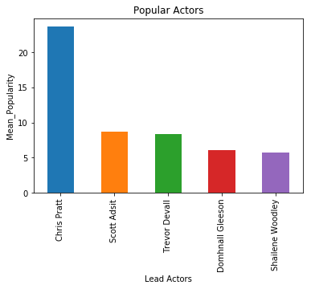

```python
#Based on the lead actors we split above we have grouped by Lead1 and the popularity mean to find the
#largest 5 lead actors.
counting=news.groupby('Lead_1').popularity.mean()
#counting
plot1=counting.nlargest(5).plot(kind='bar',title='Popular Actors');
plot1.set(xlabel="Lead Actors", ylabel="Mean_Popularity");
```

Chris Pratt is going on a roll. He is making a impact with his movies. He has huge difference from others. More than double the popularity from the 2nd most

```python
9.How does the budget and revenue changes based on last 15 years?
```

[figure not shown]

```python
# We are finding the budget for the movies based on years.
#The movies is taken above the year 2000 to calculate it
# the data is then grouped by year and the mean budget is taken and plotted using bar chart.
latest=news.query('release_year>2000')
plot1=latest.groupby('release_year').budget.mean().plot(kind='bar',title='Years based on budget')
plot1.set(xlabel="Years", ylabel="Mean Budget");
```

From the graph we can see that the budget is decreasing based on years. Thats quite bad and it must be due to 0 values.

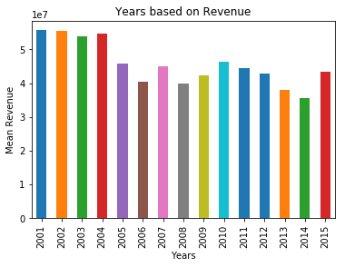

```python
plot1=latest.groupby('release_year').revenue.mean().plot(kind='bar',title='Years based on Revenue')
plot1.set(xlabel="Years", ylabel="Mean Revenue");
```

## Conclusions

From this dataset, i can understand how to do the calculations and understand the data sets. I worked on the Imdb dataset to remove the values and columns which are not suitable for analysis. Later worked on the datasets and made sure to work to create dependent and independent variables. My dependent variable is based on popularity and other columns has independent. I have analyzed various questions to conclude th analysis.

My main goal is to analyze the movie details based on its popularity. From the dataset i can able to understand the popularity between directors, lead actors and movies. The relationship between popularity and revenue created a huge difference in understanding the dataset. I overcame many attempts and failures to understand the correct sequence of Analysis.

All the questions asked above has been asnwered. I learnt many stuff in figuring out a way to analyze my finding. Some limitations i feel from the dataset is that most of the revenue and budget were marked 0. It did not provide the correct visualization. However altogether it was good.

Undertanding:

It took me some time to understand the configurations of groupby feature in this analysis. The video before the project helped me a lot. I understood many things from the video.

The other thing i found tough is to split the value from the column and add that into 5 new columns. I faced a big error. could not figure it out. Atlast the Stack over flow helped me out. I figured and understood it. I am happy with my findings.

Limitations: From the required Tmbd dataset we can see that the movies are outdated with respect to the current scenario and most of the numeric values are initialized with zero. This makes our prediction less efficiency. This Dataset did contain N number of null values and some duplicates, which affects our efficiency when comparing results.